# Automatically select the ‘knee/elbow’ of a curve

Zuguang Gu (z.gu@dkfz.de)

2021-07-29

We demonstrate the method that automatically selects the “knee/elbow” of a curve proposed in the study [Satoppa et al., 2011](https://ieeexplore.ieee.org/document/5961514).

```r
library(cola)
library(golubEsets)
data(Golub_Merge)
m = exprs(Golub_Merge)

m[m <= 1] = NA
m = log10(m)
m = adjust_matrix(m)

library(matrixStats)
s = rowSds(m)
```

Values in `s` are sorted increasingly and they are visualized as a scatterplot. Now the task is to identify the “elbow” of this curve.

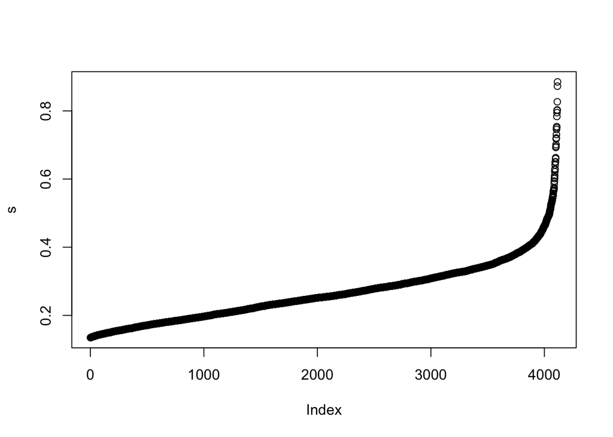

```r
s = sort(s)
plot(s)
```

[Satoppa et al., 2011](https://ieeexplore.ieee.org/document/5961514) proposed a method that selects the “elbow point” as the one having the largest distance to the straight line (denoted as $L$) that connects the two boundary points with the minimal and maximal values on *y*-axis. The method is demonstrated by the following code. Note values on both *x*-axis and *y*-axis are scaled into `[0, 1]`.

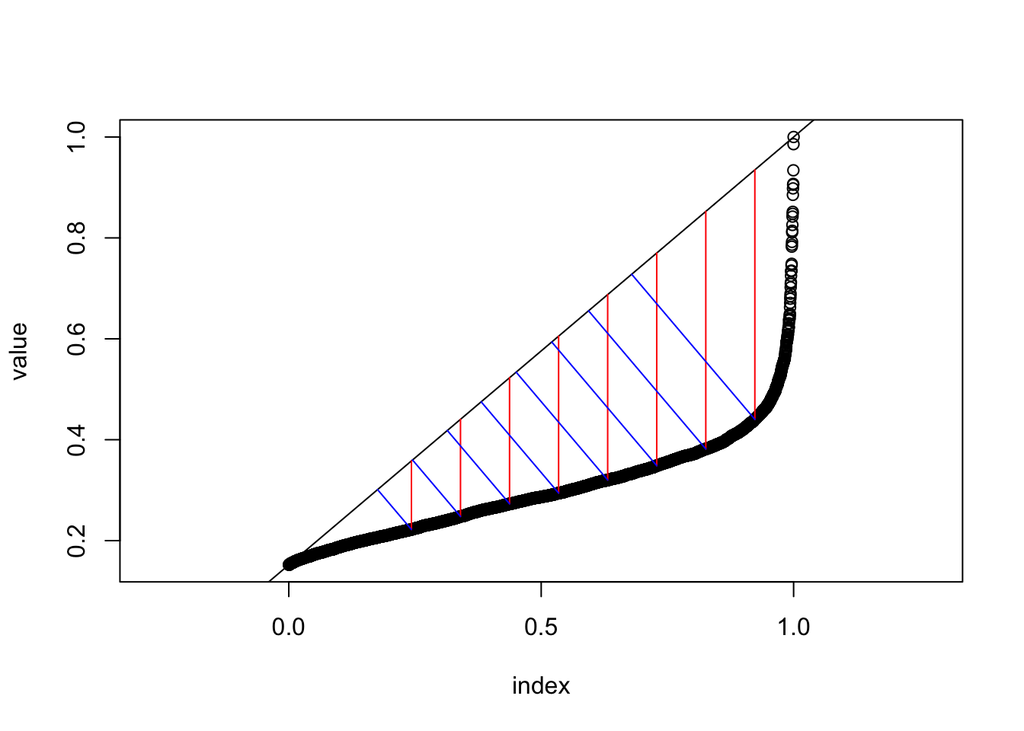

Figure S2.2. Demonstration of the method to look for elbow/knee of the curve.

```r
y = s
x = seq_along(y)

x = x/max(x)
y = y/max(y)

n = length(x)
a = (y[n] - y[1])/(x[n] - x[1])
b = y[1] - a * x[1]
d = a * x + b - y
x1 = x[which.min(d)]
x2 = x[which.max(d)]
theta = atan(a)

plot(x, y, xlab = "index", ylab = "value", asp = 1)
abline(a = b, b = a)

breaks = seq(1000, 3800, length = 8)/n
y0 = quantile(y, breaks)
y1 = a*breaks + b
segments(breaks, y0, breaks, y1, col = "red")

a2 = tan(theta + pi/2)
b2 = y0- a2*breaks
x2 = (b2 - b)/(a - a2)
y2 = a*x2 + b
segments(breaks, y0, x2, y2, col = "blue")
```

Instead of selecting by the distance to $L$ (the lengths of blue lines), we can simply select according to the vertical distance to $L$ (the lengths of red lines). The two selection rules are actually identical.

We implement this method with the function `knee_finder2()` in **cola**. The function generates two plots: the original curve and a curve of the vertical distance to $L$.

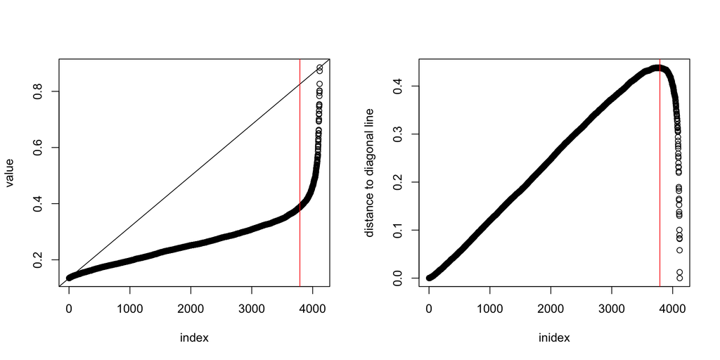

Figure S2.3. Output plots from knee_finder2().

```
## [1]   NA 3790
```

```r
knee_finder2(s, plot = TRUE)
```

`knee_finder()` returns a vector of two. The second value corresponds to the elbow of the curve and the first value corresponds to the knee of the curve, as shown in the following plot.

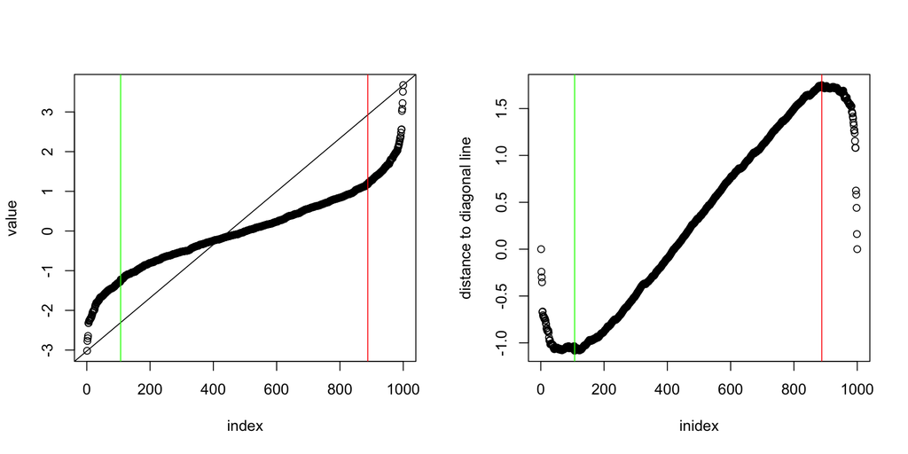

Figure S2.4. When both knee and elbow exist in the curve.

```
## [1] 107 888
```

```r
s = rnorm(1000)
knee_finder2(s, plot = TRUE)
```